# 1 Quasi-random numbers for copula models via conditional distribution method

In this vignette, we present some findings around quasi-random numbers for copula models; see also Cambou et al. (2016, “Quasi-random numbers for copula models'').

```r
library(lattice)
library(gridExtra)
library(copula)
library(VineCopula)
library(randtoolbox)
library(qrng)
library(VGAM)
```

## 1 Quasi-random numbers for copula models via conditional distribution method

### Independence copula

Let's start with something know, the independence case.

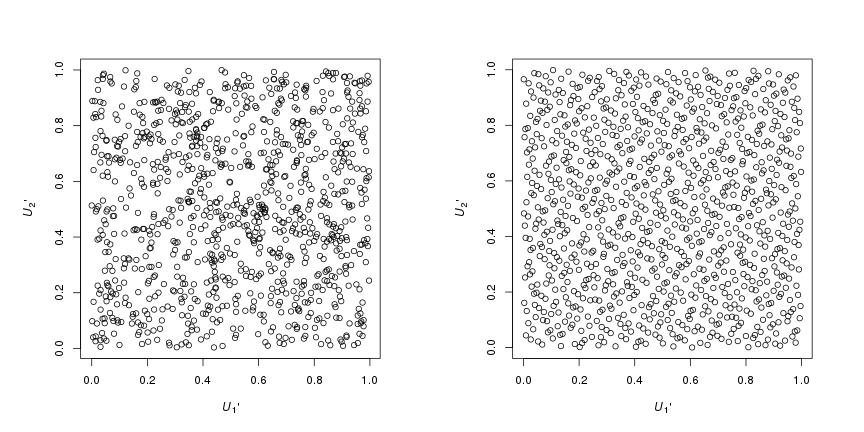

```r
n <- 1000 # sample size
set.seed(271) # set the seed (for reproducibility)
U <- matrix(runif(n*2), ncol=2) # pseudo-random numbers
U. <- halton(n, dim=2) # quasi-random numbers
par(pty="s", mfrow=1:2)
plot(U,  xlab=expression(italic(U)[1]*"'"), ylab=expression(italic(U)[2]*"'"))
plot(U., xlab=expression(italic(U)[1]*"'"), ylab=expression(italic(U)[2]*"'"))
```

Let's check if the more equally spaced points (less gaps, less clusters) are preserved in the copula world when determined with one-to-one transformations (such as the conditional distribution method (CDM); this can be obtained via `cCopula(, inverse=TRUE)`).

### \(t\) copula with three degrees of freedom

Consider a \(t\) copula with three degrees of freedom.

```r
family <- "t"
nu <- 3 # degrees of freedom
tau <- 0.5 # Kendall's tau (determines the copula parameter rho)
th <- iTau(ellipCopula(family, df=nu), tau)
cop <- ellipCopula(family, param=th, df=nu)
```

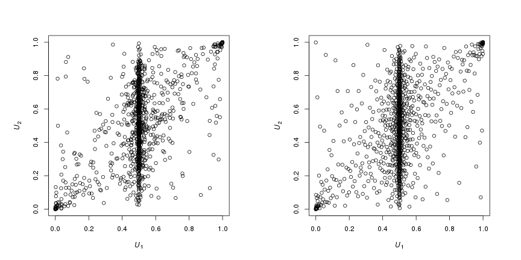

```r
U.t  <- cCopula(U,  copula = cop, inverse = TRUE) # via PRNG
U.t. <- cCopula(U., copula = cop, inverse=TRUE) # via QRNG
par(pty="s", mfrow=1:2)
plot(U.t,  xlab=expression(italic(U)[1]), ylab=expression(italic(U)[2]))
plot(U.t., xlab=expression(italic(U)[1]), ylab=expression(italic(U)[2]))
```

### Clayton copula

```r
family <- "Clayton"
tau <- 0.5
th <- iTau(getAcop(family), tau)
cop <- onacopulaL(family, nacList=list(th, 1:2))
```

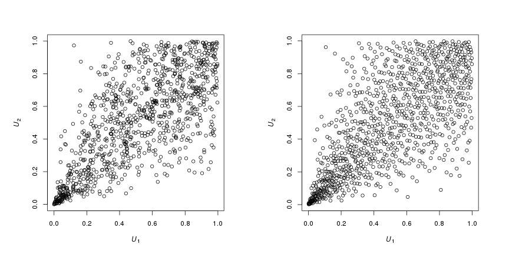

```r
U.C  <- cCopula(U,  copula = cop, inverse = TRUE) # via PRNG
U.C. <- cCopula(U., copula = cop, inverse = TRUE) # via QRNG
par(pty="s", mfrow=1:2)
plot(U.C,  xlab=expression(italic(U)[1]), ylab=expression(italic(U)[2]))
plot(U.C., xlab=expression(italic(U)[1]), ylab=expression(italic(U)[2]))
```

### Marshall–Olkin copula

```r
alpha <- c(0.25, 0.75)
tau <- (alpha[1]*alpha[2]) / (alpha[1]+alpha[2]-alpha[1]*alpha[2])
```

```r
##' @title Inverse of the bivariate conditional Marshall--Olkin copula
##' @param u (n,2) matrix of U[0,1] random numbers to be transformed to
##'        (u[,1], C^-(u[,2]|u[,1]))
##' @param alpha bivariate parameter vector
##' @return (u[,1], C^-(u[,2]|u[,1])) for C being a MO copula
##' @author Marius Hofert
inv_cond_cop_MO <- function(u, alpha)
{
    stopifnot(is.matrix(u), 0 <= alpha, alpha <= 1)
    up <- u[,1]^(alpha[1]*(1/alpha[2]-1))
    low <- (1-alpha[1])*up
    i1 <- u[,2] <= low
    i3 <- u[,2] >  up
    u2 <- u[,1]^(alpha[1]/alpha[2])
    u2[i1] <- u[i1,1]^alpha[1] * u[i1,2] / (1-alpha[1])
    u2[i3] <- u[i3,2]^(1/(1-alpha[2]))
    cbind(u[,1], u2)
}
```

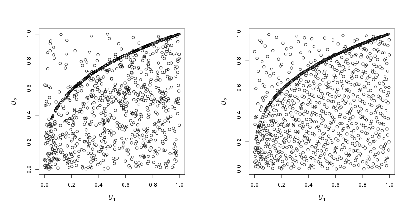

```r
U.MO  <- inv_cond_cop_MO(U, alpha=alpha)
U.MO. <- inv_cond_cop_MO(U., alpha=alpha)
par(pty="s", mfrow=1:2)
plot(U.MO,  xlab=expression(italic(U)[1]), ylab=expression(italic(U)[2]))
plot(U.MO., xlab=expression(italic(U)[1]), ylab=expression(italic(U)[2]))
```

### 3d \(t\) copula with three degrees of freedom

Let's consider a three-dimensional \(t\) copula with three degrees of freedom.

```r
family <- "t"
nu <- 3 # degrees of freedom
tau <- 0.5 # Kendall's tau (determines the copula parameter rho)
th <- iTau(ellipCopula(family, df=nu), tau)
cop <- ellipCopula(family, param=th, dim=3, df=nu)
```

First the pseudo-random version.

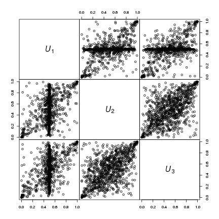

```r
U.3d <- matrix(runif(n*3), ncol=3)
U.t.3d <- cCopula(U.3d, copula = cop, inverse = TRUE)
par(pty="s")
pairs(U.t.3d, gap=0,
      labels=as.expression(sapply(1:3, function(j) bquote(italic(U[.(j)])))))
```

Now the quasi-random version.

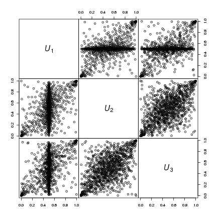

```r
U.3d. <- halton(n, dim=3)
U.t.3d. <- cCopula(U.3d., copula = cop, inverse = TRUE)
par(pty="s")
pairs(U.t.3d., gap=0,
      labels=as.expression(sapply(1:3, function(j) bquote(italic(U[.(j)])))))
```

Note that projections (here: to pairs) can appear not to be quasi-random' (or appear not to possess a lower discrepancy), but see Section 2.2 below! Visualization in more than two dimensions seems difficult; we have just seen bivariate projections and 'quasi-randomness' is also not easily visible from a 3d cloud plot.

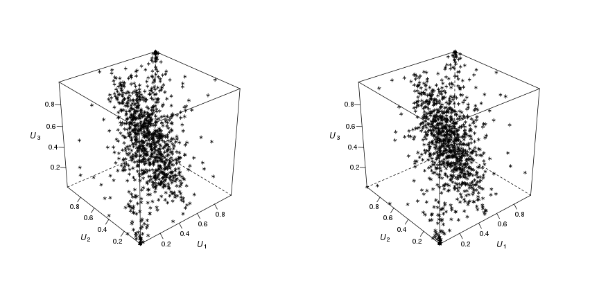

```r
p1 <- cloud(U.t.3d[,3]~U.t.3d[,1]+U.t.3d[,2], scales=list(col=1, arrows=FALSE), col=1,
            xlab=expression(italic(U)[1]), ylab=expression(italic(U)[2]),
            zlab=expression(italic(U[3])),
            par.settings=list(background=list(col="#ffffff00"),
                              axis.line=list(col="transparent"), clip=list(panel="off")))
p2 <- cloud(U.t.3d.[,3]~U.t.3d.[,1]+U.t.3d.[,2], scales=list(col=1, arrows=FALSE), col=1,
            xlab=expression(italic(U)[1]), ylab=expression(italic(U)[2]),
            zlab=expression(italic(U[3])),
            par.settings=list(background=list(col="#ffffff00"),
                              axis.line=list(col="transparent"), clip=list(panel="off")))
grid.arrange(p1, p2, ncol=2)
```

### 3d R-Vine copula

As another example, consider a three-dimensional R-vine copula.

```r
M <- matrix(c(3, 1, 2,
              0, 2, 1,
              0, 0, 1), ncol=3) # R-vine tree structure matrix
family <- matrix(c(0, 3, 3, # C, C
                   0, 0, 3, #    C
                   0, 0, 0), ncol=3) # R-vine pair-copula family matrix (0 = Pi)
param <- matrix(c(0, 1, 1,
                  0, 0, 1,
                  0, 0, 0), ncol=3) # R-vine pair-copula parameter matrix
param. <- matrix(0, nrow=3, ncol=3) # 2nd R-vine pair-copula parameter matrix
RVM <- RVineMatrix(Matrix=M, family=family, par=param, par2=param.) # RVineMatrix object
```

First the pseudo-random version.

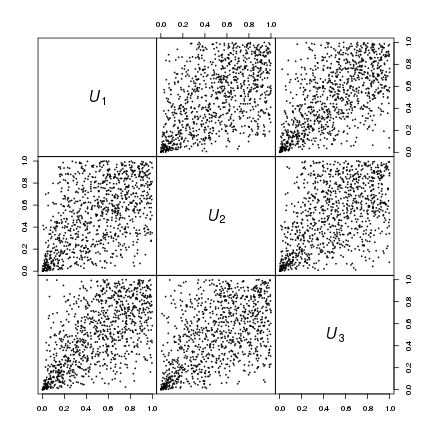

```r
U <- RVineSim(n, RVM) # PRNG
par(pty="s")
pairs(U, labels=as.expression( sapply(1:3, function(j) bquote(italic(U[.(j)]))) ),
      gap=0, cex=0.3)
```

Now the quasi-random version.

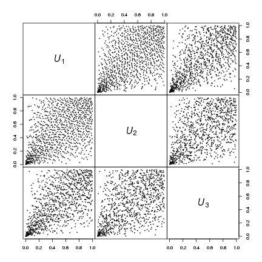

```r
U. <- RVineSim(n, RVM, U=halton(n, d=3)) # QRNG
par(pty="s")
pairs(U., labels=as.expression( sapply(1:3, function(j) bquote(italic(U[.(j)]))) ),
      gap=0, cex=0.3)
```

Similarly to the 3d *t* copula case (because of the projections to pairs), not all pairs appear to be 'quasi-random'.

## 2 Quasi-random numbers for copula models via stochastic representations

For many copula families, it is rarely efficient to sample them via the CDM (or other one-to-one transformations), one typically uses stochastic representations based on simple, easy-to-sample distributions as building blocks. Although, again, not directly visible, quasi-random numbers can also improve the low-discrepancy of the resulting random numbers and thus be used for variance reduction in the context of dependence.

### 2.1 Colorized scatter plot

To explore this, we sample from a Clayton copula via the CDM (so via a one-to-one transformation) and via the Marshall–Olkin algorithm (so via a stochastic representation in terms of the Gamma frailty distribution and two standard exponentials) based on a three-dimensional Halton sequence.

```r
n <- 1000
family <- "Clayton"
tau <- 0.5
th <- iTau(getAcop(family), tau)
cop <- onacopulaL(family, nacList=list(th, 1:2))
```

```r
## Generate dependent samples
U <- halton(n, 3)
U_CDM <- cCopula(U[,1:2], copula = cop, inverse = TRUE) # via CDM
U_MO <- copClayton@psi(-log(U[,2:3]) / qgamma(U[,1], 1/th), theta=th) # via Marshall-Olkin (MO)

## Colorization of U[,1:2]
col <- rep("black", n)
col[U[,1] <= 0.5 & U[,2] <= 0.5] <- "maroon3"
col[U[,1] >= 0.5 & U[,2] >= 0.5] <- "royalblue3"

## Colorization of U[,1:3] (= U)
col. <- rep("black", n)
col.[apply(U <= 0.5, 1, all)] <- "maroon3"
col.[apply(U >= 0.5, 1, all)] <- "royalblue3"
```

#### Colorized scatter plot (quasi-random numbers and CDM)

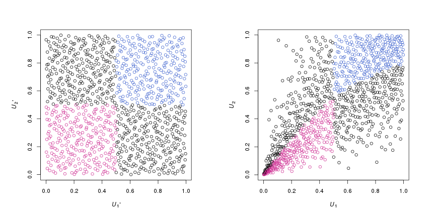

```r
par(pty="s", mfrow=1:2)
plot(U[,1:2], xlab=expression(italic(U)[1]*"'"), ylab=expression(italic(U)[2]*"'"), col=col)
plot(U_CDM,   xlab=expression(italic(U)[1]), ylab=expression(italic(U)[2]), col=col)
```

#### Colorized scatter plots (quasi-random numbers and MO)

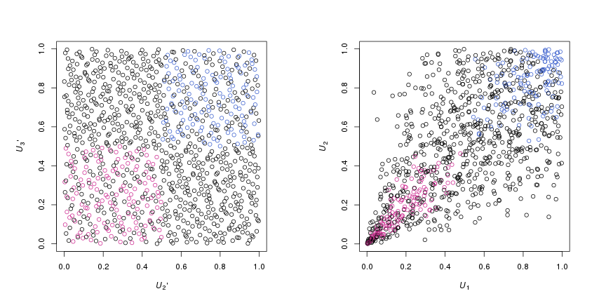

```r
par(pty="s", mfrow=1:2)
plot(U[,2:3], xlab=expression(italic(U)[2]*"'"), ylab=expression(italic(U)[3]*"'"), col=col.)
plot(U_MO, xlab=expression(italic(U)[1]), ylab=expression(italic(U)[2]), col=col.)
```

### 2.2 A variance-reduction example

In this example, we would like to investigate the standard deviation when estimating expected shortfall at \(\alpha=99\%\) confidence level via Monte Carlo simulation based on a Clayton copula with Pareto margins. To this end we consider pseudo-random numbers and quasi-random numbers, as well as two different sampling methods for the Clayton copula (the conditional distribution method and the Marshall–Olkin method (based on a well-known stochastic representation)), hence four different sampling methods.

Here is our setup.

```r
n <- round(2^seq(12, 16, by=0.5)) # sample sizes
B <- 25 # number of replications
d <- 5 # dimension
tau <- 0.5 # Kendall's tau
theta <- iTau(getAcop("Clayton"), tau) # copula parameter
qPar <- function(p, theta=3) (1-p)^(-1/theta)-1 # marginal Pareto quantile function
rng.methods <- c("runif", "ghalton") # random number generation methods
cop.methods <- c("CDM", "MO") # copula sampling methods (conditional distribution method and Marshall--Olkin)
alpha <- 0.99 # confidence level
```

Next, let's implement a function which can sample the Clayton copula with one of the four approaches.

```r
##' @title Pseudo-/quasi-random number generation for (survival) Clayton copulas
##' @param n Sample size
##' @param d Dimension
##' @param B Number of replications
##' @param theta Clayton parameter
##' @param survival Logicial indicating whether a sample from the survival copula
##'        should be returned
##' @param rng.method Pseudo-/quasi-random number generator
##' @param cop.method Method to construct the pseudo-/quasi-random copula sample
##' @return (n, d, B)-array of pseudo-/quasi-random copula sample
##' @author Marius Hofert
rng_Clayton <- function(n, d, B, theta, survival=FALSE,
                        rng.method=c("runif", "ghalton"),
                        cop.method=c("CDM", "MO"))
{
    ## Sanity checks
    stopifnot(n >= 1, d >= 2, B >= 1, is.logical(survival))
    rng.method <- match.arg(rng.method)
    cop.method <- match.arg(cop.method)

    ## Draw U(0,1) random numbers
    k <- if(cop.method=="CDM") d else d+1
    U. <- switch(rng.method,
    "runif" = {
        array(runif(n*k*B), dim=c(n,k,B)) # (n, k, B)-array
    },
    "ghalton" = {
        replicate(B, expr=ghalton(n, d=k)) # (n, k, B)-array
    },
    stop("Wrong 'rng.method'"))

    ## Convert to pseudo-/quasi-random copula samples
    U <- switch(cop.method, # B-list of (n, d)-matrices
    "CDM" = {
        cop <- onacopulaL("Clayton", nacList=list(theta, 1:d)) # d=k here
        lst <- apply(U., 3, FUN=function(x) list(cCopula(x, copula = cop, inverse = TRUE)))
        lapply(lst, `[[`, 1)
    },
    "MO" = {
        lapply(1:B, function(b) {
            copClayton@psi(-log(U.[,2:k,b]) / qgamma(U.[,1,b], 1/theta), theta=theta)
        })
    },
    stop("Wrong 'cop.method'"))

    ## Return
    if(survival) 1-U else U # B-list of (n, d)-matrices
}
```

We also need an estimator of expected shortfall; we use the empirical estimator here.

```r
ES <- function(x, alpha) mean(x[x > quantile(x, probs=alpha, type=1)])
```

For each of the four methods, each of the chosen sample sizes and the number \(B\) of (bootstrap) replications considered here, generated the samples, aggregate them and compute expected shortfall at the 99\% confidence level. To reduce increase comparability, note that samples with smaller sample size are subsets of samples with larger sample size.

```r
set.seed(271)
res.ES <- array(, dim=c(length(n), length(cop.methods), length(rng.methods), B),
                dimnames=list(n=n, cop.meth=cop.methods, rng.meth=rng.methods, B=1:B))
for(cmeth in cop.methods) {
    for(rmeth in rng.methods) {
        ## Generate Clayton dependent random numbers with Par(3) margins
        U <- rng_Clayton(max(n), d=d, B=B, theta=theta,
                         rng.method=rmeth, cop.method=cmeth)
        X <- lapply(U, qPar) # B-list of (max(n), d)-matrices
        ## Iterate over different sample sizes
        for(k in seq_along(n)) {
            ## Pick out samples we work with
            X. <- lapply(X, function(x) x[1:n[k],]) # B-list of (n[k], d)-matrices
            ## Aggregate losses
            L <- sapply(X., rowSums) # (n[k], B)-matrix
            ## Estimate ES
            res.ES[k,cmeth,rmeth,] <- apply(L, 2, ES, alpha=alpha) # B-vector of ES's
        }
    }
}
```

Now we can compute the standard deviations, including estimated power curves based on all data stemming from pseudo-random numbers and all data stemming from quasi-random numbers.

```r
## Compute standard deviations
res <- apply(res.ES, 1:3, sd) # (n, cop.methods, rng.methods)
## Fit linear models to the curves
## All pseudo-quantities
res.p <- data.frame(n=rep(n, 2), sd=c(res[,"CDM","runif"], res[,"MO","runif"]))
cf.lm.p <- coef( lm(log(sd) ~ log(n), data = res.p) )
c.p <- exp(cf.lm.p[[1]])
a.p <- cf.lm.p[[2]]
y.p <- c.p * n^a.p # log(y) = -a*log(n)+b <=> y = exp(b)*n^(-a)
## All quasi-quantities
res.q <- data.frame(n=rep(n, 2), sd=c(res[,"CDM","ghalton"], res[,"MO","ghalton"]))
lm.q <- lm(log(sd)~log(n), data=res.q)
c.q <- exp(lm.q$coefficients[[1]])
a.q <- lm.q$coefficients[[2]]
y.q <- c.q * n^a.q
```

And now the results. In a nutshell, in comparison to pseudo-random numbers, quasi-random numbers for copula models can reduce the standard deviations (or variances), and this holds not only for one-to-one transformations such as the conditional distribution method but also for well-known stochastic representations such as Marshall–Olkin's. Note that the results are more pronounced for larger sample sizes; see also Cambou et al. (2016, Quasi-random numbers for copula models'').

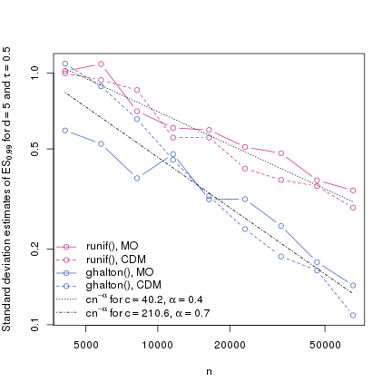

```r
plot(n, res[,"CDM","runif"], xlab="n", type="b", log="xy", ylim=range(res, y.p, y.q),
     ylab=substitute("Standard deviation estimates of"~ES[a]~"for"~d==d.~"and"~tau==tau.,
                     list(a=alpha, d.=d, tau.=tau)), lty=2, col="maroon3") # CDM & runif()
lines(n, res[,"CDM","ghalton"], type="b", lty=2, col="royalblue3") # CDM & ghalton()
lines(n, res[,"MO","runif"], type="b", lty=1, col="maroon3") # MO & runif()
lines(n, res[,"MO","ghalton"], type="b", lty=1, col="royalblue3") # MO & ghalton()
lines(n, y.p, lty=3) # approximate curve y = c * n^{-alpha} to the pseudo-data
lines(n, y.q, lty=4) # approximate curve y = c * n^{-alpha} to the quasi-data
legend("bottomleft", bty="n", lty=c(1,2,1,2,3,4),pch=c(1,1,1,1,NA,NA),
       col=c(rep(c("maroon3", "royalblue3"), each=2), rep("black", 2)),
       legend=as.expression(c("runif(), MO", "runif(), CDM", "ghalton(), MO", "ghalton(), CDM",
                              substitute(cn^{-alpha}~"for"~c==c.*","~alpha==a.,
                                         list(c.=round(c.p, 1), a.=abs(round(a.p, 1)))),
                              substitute(cn^{-alpha}~"for"~c==c.*","~alpha==a.,
                                         list(c.=round(c.q, 1), a.=abs(round(a.q, 1)))))))
```